DS 6030 | Fall 2024 | University of Virginia

# Homework #0: Hello DS-6030

Author

**SOLUTIONS**

Published

Fall 2024

**Warning**

These solutions are only for the private use of the students of DS 6030 Fall 2024. Sharing of the solutions, posting on the internet, selling to a company, or possession by anyone outside of the class constitutes a violation of the honor policy.

# Required R packages and Directories

```r
data_dir = 'https://mdporter.github.io/teaching/data/' # data directory
library(tidyverse) # functions for data manipulation
```

# Getting Help

The purpose of this (ungraded) homework is to help get you prepared for the semester. Don’t panic if you don’t immediately know the answers to some of these. I expect everyone will need to look things up. Take note of the areas that are rusty and plan to spend a bit of extra time to get up to speed. If some of these items are not even remotely familiar to you, then you probably have not satisfied the pre-requisite material; review the course syllabus and speak to me about any questions.

The teaching staff (TA and myself) are here to help! Don’t wait too long before asking for help and do let us know right away if you are starting to fall behind. I will also publish the solutions after due date. It is **highly encouraged** that you study the posted solutions.

# R Resources

## a. Update R, RStudio, and Quarto

- Use the latest version (R 4.4.1, RStudio 2024.04.2+764, Quarto 1.3.450)
- Installation help
  - R: https://cran.rstudio.com/
  - RStudio: https://posit.co/download/rstudio-desktop/
  - Quarto: https://quarto.org/docs/get-started/

## b. Install/Update the following packages we will meet during this course:

- Dynamic report generation: `rmarkdown`, `knitr`, `quarto`
- Utility: `remotes`
- Working with Data: `tidyverse`
- Data: `ISLR`, `moderndive`, `MASS`
- Resampling: `boot`, `rsample`
- Modeling: `tidymodels`, `modelr`, `broom`
- Regression: `glmnet`, `FNN`,
- Classification: `e1071`,
- Trees: `rpart`, `rpart.plot`, `randomForest`, `ranger`
- Ensembles: `gbm`, `xgboost`
- Density Estimation: `fitdistrplus`, `ks`
- Clustering: `mclust`, `mixtools`
- Association Analysis: `arules`
- Networks: `igraph`
- Forecasting: `fpp3`

You can see which of your existing packages need updating by running:

```r
old.packages() %>% as_tibble()
```

Or use the `update.packages()` function to update them.

Note: Do not call `install.packages()` in this Quarto document; it only needs to be done once from the console. However you will need to use `library()` in Quarto since it needs to be called every time the document is compiled.

## c. Install the course quarto extension

This document will not compile until you load the `ds6030hw-html` quarto extension. To do this, open a terminal window (if using RStudio, look for the terminal tab) and navigate to the same directory where this file is. Then run:

```
quarto add mdporter/quarto-ds6030-hw
```

which should create an `_extensions` directory (if connected to the internet). This contains the formatting for the compiled html document.

# Tidyverse Resources

Read the following sections in [R for Data Science 2e](https://r4ds.hadley.nz/):

- The Whole Game
  - Chapters 2-9
- Visualize
  - Chapters 10-12
- Transform
  - 12-15, 19
- Program
  - 26-27
- Communicate
  - 29

# Save/Bookmark the following cheatsheets and resources

[Posit Cheatsheets](https://posit.co/resources/cheatsheets/)

## **RStudio and Quarto**

- [RStudio IDE Cheatsheet](https://rstudio.github.io/cheatsheets/html/rstudio-ide.html)
- [Quarto Website](https://quarto.org/docs/authoring/markdown-basics.html)
- [Quarto Cheatsheet](https://rstudio.github.io/cheatsheets/html/quarto.html)
- [Latex Cheatsheet](https://wch.github.io/latexsheet/latexsheet-0.png)

## **R**

- [Base R](https://rstudio.github.io/cheatsheets/base-r.pdf)
- [Data Visualization Cheatsheet](https://rstudio.github.io/cheatsheets/html/data-visualization.html)
  - [`ggplot2` website](https://ggplot2.tidyverse.org/)
- [Tidy Data Cheatsheet](https://rstudio.github.io/cheatsheets/html/tidyr.html)
  - [`tidyr` website](https://tidyr.tidyverse.org/)
- [Data Transform Cheatsheet](https://rstudio.github.io/cheatsheets/html/data-transformation.html)
  - [`dplyr` website](https://dplyr.tidyverse.org/)
- [Factors with forcats Cheatsheet](https://rstudio.github.io/cheatsheets/html/factors.html)
  - [`forcats` website](https://forcats.tidyverse.org/)
- [Data Import Cheatsheet](https://rstudio.github.io/cheatsheets/html/data-import.html)
  - [`readr` website](https://readr.tidyverse.org/)
- [Apply Functions Cheatsheet](https://rstudio.github.io/cheatsheets/html/purrr.html)
  - [`purrr` website](https://purrr.tidyverse.org/)

## **Python with RStudio/RMarkdown** (Optional)

- [Python with R and Reticulate Cheatsheet](https://rstudio.github.io/cheatsheets/html/reticulate.html)

# Problem 1: Math Notation

## a. What are the equations for the least squares coefficients in linear regression (in matrix notation)? Use $X$ for the model/design/predictor matrix, and $Y$ the vector of outcomes.

**Solution**

$$\hat{\beta} = (X^{T}X)^{-1} X^T Y$$

## b. Let $x_1, x_2, \ldots, x_n$ be a sample of length of time that a customer is on the phone with a call center help line. We feel comfortable modeling the data as coming from an *exponential distribution*. What is the MLE (Maximum Likelihood Estimate) of the parameter? Show your steps.

**Solution**

The maximum likelihood equation is

$$\begin{align*}
\hat{\lambda} &= \arg\max_{\lambda} \; L(\lambda) \\
&= \arg\max_{\lambda} \; \prod_{i=1}^n \lambda e^{-\lambda x_i} %\\
%&= \arg\max_{\lambda} \; \lambda^n \prod_{i=1}^n e^{-\lambda x_i}
\end{align*}$$

It is often easier to maximize the log-likelihood
$$\begin{align*}
\log L(\lambda) &= n\log(\lambda) - \lambda \sum_{i=1}^n x_i
\end{align*}$$
For an exponential distribution, this is easy. Just take the derivative of the log-likelihood function w.r.t. $\lambda$,
$$\frac{d \log L(\lambda)}{d \lambda} = \frac{n}{\lambda} - \sum_{i=1}^n x_i$$
set it equal to zero,

$$\frac{n}{\lambda} = \sum_{i=1}^n x_i$$
and solve for $\lambda$,

$$\hat{\lambda} = \frac{n}{\sum_{i=1}^n x_i} = \bar{x}^{-1}$$

# Problem 2: Coding Practice

## a. Simulate 100 observations from the following model:

- $X \sim N(1, 1)$
- $Y \sim N(1 + 2X, 2)$
- $Z = \begin{cases} 1 &\quad Y<0 \\ 2 &\quad Y \ge 0 \end{cases}$

**Solution**

```r
library(dplyr)
n = 100                   # number of observations (sample size)
set.seed(2022)            # set seed for reproducibility
data = tibble(
  X = rnorm(n, 1, 1),     # N(1,1)
  Y = rnorm(n, 1+2*X, 2), # N(1 + 2X, 2)
  Z = ifelse(Y<0, 1, 2) %>% factor()  # Make Z a factor
)
```

## b. Make a scatter plot of the data. Put $X$ on the x-axis and $Y$ on the y-axis. Color the points according to $Z$.

**Solution**

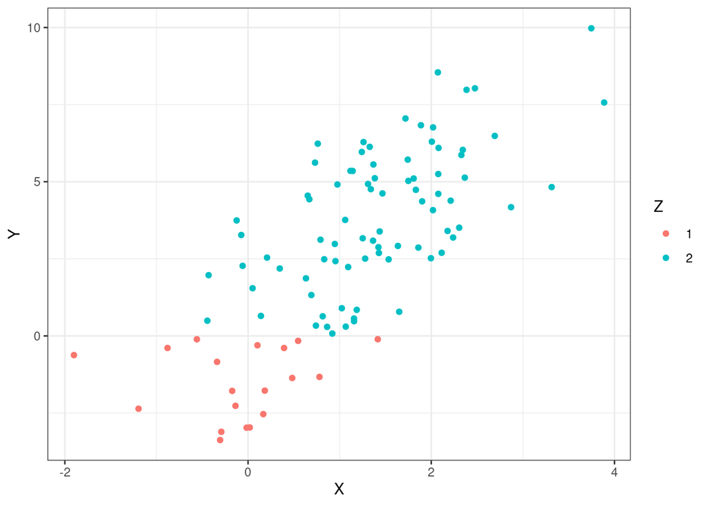

```r
library(ggplot2)
data %>%
  ggplot(aes(X, Y, color = Z)) + geom_point()
```

## c. Write a function that adds two numbers together and squares the result.

**Solution**

```r
#: basic function, no checks for valid inputs
plus_squared <- function(x, y){
  (x + y)^2
}

#: try it out
plus_squared(3, 5)
```

```
[1] 64
```

## d. Write a loop to calculate the mean of every column in (the built-in data) `mtcars`.

**Solution**

I’m going to give an example using a *for* loops, but *while* loops could also work here. Every *for* loop requires three elements:

1. Initializing the **output** structure to store results.
   - Since we are computing numeric values, a numeric vector with length the number of columns of `mtcars` would work. But do we want to *name* the vector with the column name? Or should we create a tibble with one column for the name and the other the mean?
2. The sequence to iterate over.
   - In this example, it will be the column names or positions.
3. The body of the loop.
   - In the body of the loop, we simply want to calculate the mean.

The Base R approach explicitly requires each step. Alternatively, the `purrr` solution hides the output and sequence steps.

**Base R approach**

```r
data(mtcars)  # load mtcars data
output = numeric(ncol(mtcars)) # initiate numeric vector
names(output) = colnames(mtcars)
for(j in 1:ncol(mtcars)){
  output[j] = mean(mtcars[,j])
}
output
```

```
    mpg     cyl    disp      hp    drat      wt    qsec      vs      am    gear
 20.091   6.188 230.722 146.688   3.597   3.217  17.849   0.438   0.406   3.688
   carb
  2.812
```

**Tidyverse (purrr) approach**

The `map_dbl()` function iterates over a vector/list and applies a function to each element. A data.frame (like `mtcars`) is a list where each element is a column vector.

```r
library(purrr)
data(mtcars)  # load mtcars data
purrr::map_dbl(mtcars, mean) # output = named numeric vector
```

```
    mpg     cyl    disp      hp    drat      wt    qsec      vs      am    gear
 20.091   6.188 230.722 146.688   3.597   3.217  17.849   0.438   0.406   3.688
   carb
  2.812
```

```r
purrr::map_df(mtcars, mean)  # output = data frame
```

```
# A tibble: 1 × 11
    mpg   cyl  disp    hp  drat    wt  qsec    vs    am  gear  carb
  <dbl> <dbl> <dbl> <dbl> <dbl> <dbl> <dbl> <dbl> <dbl> <dbl> <dbl>
1  20.1  6.19  231.  147.  3.60  3.22  17.8 0.438 0.406  3.69  2.81
```

# Problem 3: Statistics

## a. Find two [quantiles](https://en.wikipedia.org/wiki/Quantile) that capture 95% of the following data:

```r
set.seed(2022)
x = runif(n=100, min=2, max=22)
```

**Solution**

The 2.5% and 97.5% *sample* quantiles contain 95% of the data

```r
quantile(x, probs = c(.025, .975))
```

```
 2.5% 97.5%
 3.27 20.25
```

The *actual* quantiles are based on the distribution, e.g.

```r
qunif(c(.025, .975), min = 2, max = 22)
```

```
[1]  2.5 21.5
```

We won’t be assuming exact distributions in this course, so we have to estimate aspects of the distribution from data. This will, of course, introduce some estimation error. The field of statistics has a big emphasis on finding good estimation approaches. We alternatively could use model-based estimates, for example, recognize that the data appear to be approximately uniform and estimate the quantiles as

```r
qunif(c(.025, .975),
      min = min(x), max = max(x)) # use estimated parameters
```

```
[1]  2.54 21.46
```

This worked out better for this data sample, but we used our *prior* or *additional* knowledge of the data coming from a uniform to achieve the better results.

Technically, any two quantiles whose difference is 95% would suffice, but it is standard to use the balanced versions.

## b. Confidence Interval

A new machine learning model, developed by UVA researchers, uses biopsy images to predict if a child has enteropathy or celiac disease. [In a study of 102 patients](https://jamanetwork.com/journals/jamanetworkopen/fullarticle/2735765), the model was able to correctly classify 95 of the images.

Find the 90% [confidence interval](https://en.wikipedia.org/wiki/Confidence_interval) for the probability a patient is correctly classified?

**Solution**

This problem requires estimating a confidence interval for a proportion. Let $p$ be the true (and unknown) accuracy of the model. Our data is a sample $n=102$ patients and $x=95$ were correctly classified. What can this tell us about the unknown $p$?

There are two main approaches to estimate a confidence interval: standard error method and bootstrap method.

**Standard Error Method**

**Bootstrap Method (Percentile)**

We will introduce the bootstrap in the Resampling section of the course, but the idea is simple and powerful - something worth looking into.

A *bootstrap sample* is a sample, taken with replacement, of the original observation. If we take lots of bootstrap samples, calculate a statistic (e.g., sample proportion) from each sample, then we can estimate the distribution of the sample statistic. From this estimated distribution we can form the confidence interval.

```r
#- Observed Data
n = 102  # number of samples
y = 95   # number of successes
x = c(rep(1, y), rep(0, n-y))  # observed data (order doesn't matter)
```

```r
#- Bootstrap sample proportion
set.seed(9341)
M = 10000               # number of bootstrap samples
y.boot = numeric(M)     # initialize bootstrap statistic
for(i in 1:M){
  x.boot = sample(x, size=n, replace=TRUE)  # sample with replacement
  y.boot[i] = mean(x.boot)                  # sample proportion
}
```

```r
#: Alternative approach using purrr::map() instead of explicit loop
library(purrr)
set.seed(9341)
y.boot = map_dbl(1:M, ~sample(x, size=n, replace=TRUE) %>% mean)
```

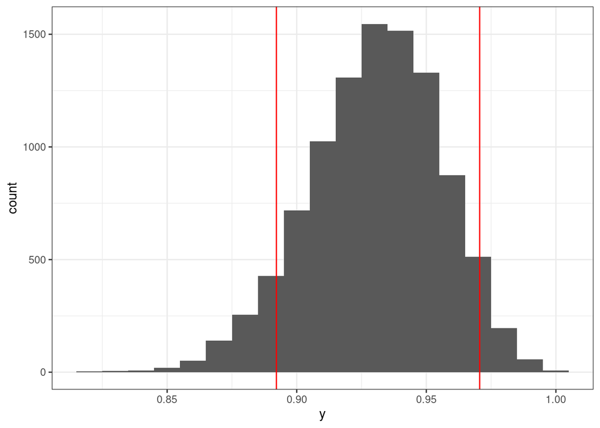

```r
#- visualize
ggplot(tibble(y = y.boot)) +
  geom_histogram(aes(y), binwidth = .01) +
  geom_vline(xintercept = quantile(y.boot, probs = c(.05, .95)), color="red")
```

```r
#- percentile CI
CI = quantile(y.boot, probs = c(.05, .95))
```

Which gives a (percentile) bootstrap based confidence interval for the model accuracy of
$$\text{CI}(p) = [0.892, 0.971]$$

These solutions lose their validity if the samples are not independent. Another issue relevant to this course is that the performance may not have been estimated from the correct data. If the study used data not reflective of the actual population of potential patients or if performance was reported on in-sample data, then the results won’t reflect reality.

## c. Linear Models

- Albemarle County, VA real estate assessment data can be found [at this link](https://raw.githubusercontent.com/uvastatlab/phdplus/master/data/albemarle_homes.csv). Data collected by UVAs StatLab as part of the PhDplus program (https://github.com/uvastatlab/phdplus).
1. Fit a linear regression model that predicts the `totalvalue` using the predictors: `condition`, size (`finsqft`), and location (`city`).
2. What are the estimated coefficients?
3. What is the estimated `totalvalue` for home with the following characteristics?

| finsqft | city | condition |
| --- | --- | --- |
| 2500 | EARLYSVILLE | Good |
| 1850 | CROZET | Fair |

**Solution**

```r
library(tidyverse) # for read_csv(), tibble(), mutate(), %>%

#: Load Data
url = 'https://raw.githubusercontent.com/uvastatlab/phdplus/master/data/albemarle_homes.csv'
homes = read_csv(url)

#: Fit Model
fit = lm(totalvalue ~ condition + finsqft + city,
         data = homes)

#: Get coefficients
library(broom)  # for tidy(), glance(), and augment()
broom::tidy(fit)
```

```
# A tibble: 17 × 5
  term               estimate std.error statistic  p.value
  <chr>                 <dbl>     <dbl>     <dbl>    <dbl>
1 (Intercept)        -143131.    11452.   -12.5   9.14e-36
2 conditionExcellent   30895.     5644.     5.47  4.43e- 8
3 conditionFair        21744.     8541.     2.55  1.09e- 2
4 conditionGood        -8576.     3127.    -2.74  6.09e- 3
5 conditionNone       -85040.    14370.    -5.92  3.30e- 9
6 conditionPoor        17524.    19049.     0.920 3.58e- 1
# ℹ 11 more rows
```

```r
#: Predictions
pred_data = tibble(
      finsqft = c(2500, 1850),
      city = c('EARLYSVILLE', 'CROZET'),
      condition = c('Good', 'Fair')
    )

# approach 1
broom::augment(fit, newdata = pred_data)  # using augment()
```

```
# A tibble: 2 × 4
  finsqft city        condition .fitted
    <dbl> <chr>       <chr>       <dbl>
1    2500 EARLYSVILLE Good      500635.
2    1850 CROZET      Fair      360076.
```

```r
# approach 2
pred_data %>%
  mutate(yhat = predict(fit, .)) # using predict() directly
```

```
# A tibble: 2 × 4
  finsqft city        condition    yhat
    <dbl> <chr>       <chr>       <dbl>
1    2500 EARLYSVILLE Good      500635.
2    1850 CROZET      Fair      360076.
```

## d. Hypothesis Testing

Use the `movies_sample` (IMDb) data from the `moderndive` R package to performance a hypothesis test that *Action* movies are ranked lower (on average) than *Romance* movies.

**Solution**

```r
# load the data
data(movies_sample, package="moderndive")
```

**Formula Interface**

```r
# Using formula with t.test()
t.test(rating ~ genre,
       data = movies_sample,
       alternative = "less")
```

```
    Welch Two Sample t-test

data:  rating by genre
t = -3, df = 66, p-value = 0.002
alternative hypothesis: true difference in means between group Action and group Romance is less than 0
95 percent confidence interval:
   -Inf -0.446
sample estimates:
 mean in group Action mean in group Romance
                 5.28                  6.32
```

**Vector Interface**

```r
# Alternative vector approach
movies_list = movies_sample %>% split(.$genre)
t.test(
  x = movies_list$Action$rating,
  y = movies_list$Romance$rating,
  alternative = "less"
  )
```

```
    Welch Two Sample t-test

data:  movies_list$Action$rating and movies_list$Romance$rating
t = -3, df = 66, p-value = 0.002
alternative hypothesis: true difference in means is less than 0
95 percent confidence interval:
   -Inf -0.446
sample estimates:
mean of x mean of y
     5.28      6.32
```

Looks like in the 68 sample of movies, *Action* movies get rated significantly (in the statistical sense with 95% confidence) lower than *Romance* movies. How sweet :)

Think about it: instead of movie ratings consider that we have predictions (and squared errors or inaccuracies) from two predictive models *on the same test data*. What would you do differently?